# Classifying Unilateral Dumbbell Biceps Curl based on activity data

Vv

01/25/2015

## Dataset description

```
Six young health participants were asked to perform one set of 10 repetitions of the Unilateral Dumbbell Biceps Curl in five different fashions:

exactly according to the specification (Class A),
throwing the elbows to the front       (Class B),
lifting the dumbbell only halfway      (Class C),
lowering the dumbbell only halfway     (Class D)
and throwing the hips to the front     (Class E).

Class A corresponds to the specified execution of the exercise, while the other 4 classes correspond to common mistakes.
```

Full description on dataset available [here](http://groupware.les.inf.puc-rio.br/har#weight_lifting_exercises)

## Working with data

##### Preparing workspace

```r
library(caret);
```

```r
library(rpart);
#library(rpart.plot);
library(rattle);
library(randomForest);
set.seed(42);
```

#### Loading and initial cleaning

```r
trainData <- read.csv("pml-training.csv", na.strings=c("NA","#DIV/0!", ""));
testData  <- read.csv('pml-testing.csv',  na.strings=c("NA","#DIV/0!", ""));
#sweep out empty rows within train and test data
trainData <- trainData[,colSums(is.na(trainData)) == 0];
testData  <- testData[,colSums(is.na(testData)) == 0];

#variables user_name, *timestamp* are irrelevant for exploration
irreleventIdxs <- grep("(*timestamp*)|(user_name)|(*_window)|(X)", names(trainData));
print(sprintf("removing variables from positions %s", paste(irreleventIdxs, collapse=', ')) );
```

```
## [1] "removing variables from positions 1, 2, 3, 4, 5, 6, 7"
```

```r
trainData   <- trainData[, -irreleventIdxs];
testData    <- testData[, -irreleventIdxs];
```

##### Data partitioning

Nothing special here. Random subsampling without replacement. One partition for model training, one for model testing.

```r
trainIdxs <- createDataPartition(y=trainData$classe, p=0.75, list=FALSE);
subTrain  <- trainData[trainIdxs, ];
subTest   <- trainData[-trainIdxs, ];
```

##### Data overview

Nothing special here, too. Just a histogram to view at the data from one of lot possible points of view.

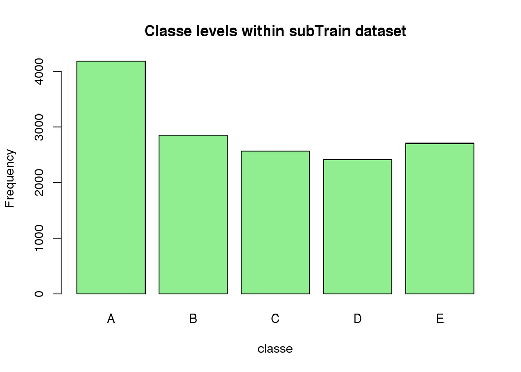

```r
plot(subTrain$classe, col="lightgreen", main="Classe levels within subTrain dataset", xlab="classe", ylab="Frequency");
```

#### Before we start

##### Strategy

Strategy is as follows: train a cople two models, then choose the best(with highest accuracy).

##### Cross-validation and out-of-sample error

Original training data will be partitioned into 2 subsets: subTrain data(75% of original dataset) - used for model training; subTest data(25%) - used for model validation. The winner will be used on original testing data. We can expect high accuracy (and low out-of-sample error) given data “describe” variablity well and model “absorbs” variability well.

##### Attempt/candidate #1: Decision tree-based model

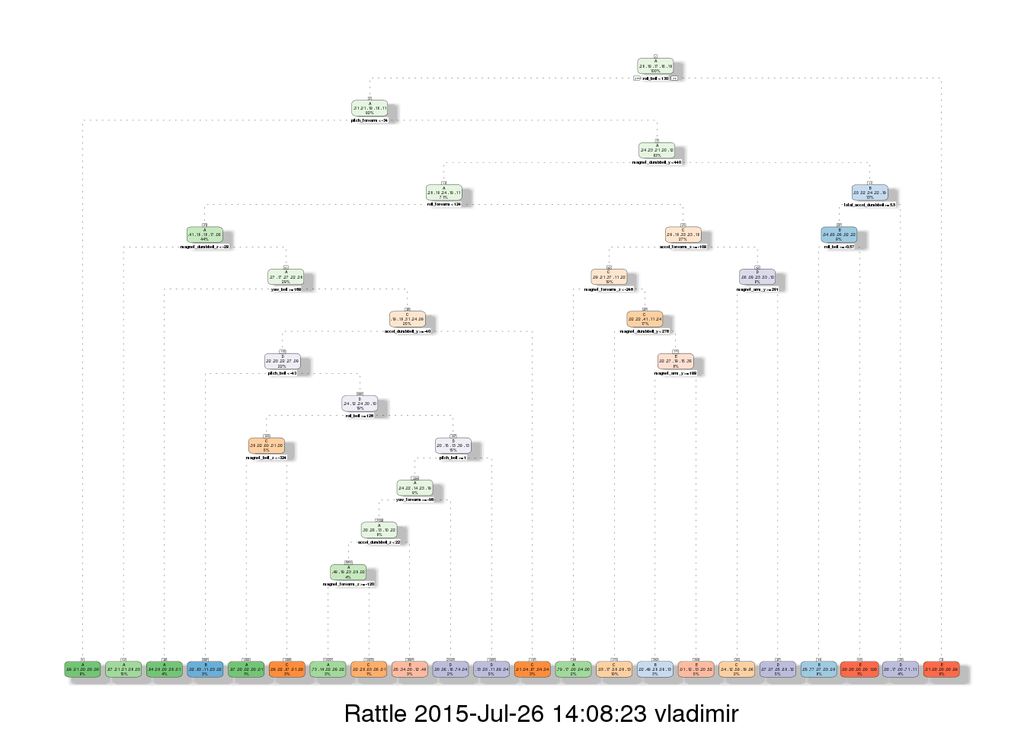

```r
m1 <- rpart(classe ~ ., data=subTrain, method="class");
# Predicting:
p1 <- predict(m1, subTest, type = "class");
# Plot of the Decision Tree
#rpart.plot(m1, main="Classification Tree", extra=102, under=TRUE, faclen=0);
fancyRpartPlot(m1);
```

```r
print(confusionMatrix(p1, subTest$classe));
```

```
## Confusion Matrix and Statistics
##
##           Reference
## Prediction    A    B    C    D    E
##          A 1275  210   11   92   24
##          B   25  460   86   32   67
##          C   30  135  675   65   84
##          D   46   46   67  560   66
##          E   19   98   16   55  660
##
## Overall Statistics
##
##                Accuracy : 0.7402
##                  95% CI : (0.7277, 0.7524)
##     No Information Rate : 0.2845
##     P-Value [Acc > NIR] : < 2.2e-16
##
##                   Kappa : 0.6699
##  Mcnemar's Test P-Value : < 2.2e-16
##
## Statistics by Class:
##
##                      Class: A Class: B Class: C Class: D Class: E
## Sensitivity            0.9140   0.4847   0.7895   0.6965   0.7325
## Specificity            0.9040   0.9469   0.9224   0.9451   0.9530
## Pos Pred Value         0.7909   0.6866   0.6825   0.7134   0.7783
## Neg Pred Value         0.9635   0.8845   0.9540   0.9408   0.9406
## Prevalence             0.2845   0.1935   0.1743   0.1639   0.1837
## Detection Rate         0.2600   0.0938   0.1376   0.1142   0.1346
## Detection Prevalence   0.3287   0.1366   0.2017   0.1601   0.1729
## Balanced Accuracy      0.9090   0.7158   0.8560   0.8208   0.8428
```

##### Attempt/candidate #2: Random forest-based model

```r
m2 <- randomForest(classe ~. , data=subTrain, method="class");
p2 <- predict(m2, subTest, type = "class");
print(confusionMatrix(p2, subTest$classe));
```

```
## Confusion Matrix and Statistics
##
##           Reference
## Prediction    A    B    C    D    E
##          A 1395    4    0    0    0
##          B    0  945    5    0    0
##          C    0    0  850    9    0
##          D    0    0    0  795    1
##          E    0    0    0    0  900
##
## Overall Statistics
##
##                Accuracy : 0.9961
##                  95% CI : (0.994, 0.9977)
##     No Information Rate : 0.2845
##     P-Value [Acc > NIR] : < 2.2e-16
##
##                   Kappa : 0.9951
##  Mcnemar's Test P-Value : NA
##
## Statistics by Class:
##
##                      Class: A Class: B Class: C Class: D Class: E
## Sensitivity            1.0000   0.9958   0.9942   0.9888   0.9989
## Specificity            0.9989   0.9987   0.9978   0.9998   1.0000
## Pos Pred Value         0.9971   0.9947   0.9895   0.9987   1.0000
## Neg Pred Value         1.0000   0.9990   0.9988   0.9978   0.9998
## Prevalence             0.2845   0.1935   0.1743   0.1639   0.1837
## Detection Rate         0.2845   0.1927   0.1733   0.1621   0.1835
## Detection Prevalence   0.2853   0.1937   0.1752   0.1623   0.1835
## Balanced Accuracy      0.9994   0.9973   0.9960   0.9943   0.9994
```

#### Results

Random forest-based model(Accuracy: 0.9961; 95% Conf. Interval(CI) : (0.994, 0.9977)) is the winner over decision tree-based(Accuracy: 0.7402; 95% CI : (0.7277, 0.7524)), with no doubt, but it takes much, MUCH more time to train.

#### Calculating out-of-sample error

```r
accuracy <- sum(p2 == subTest$classe)/length(p2);
oosError <- 1 - accuracy;
print(paste0("Out-of-sample estimation: ", round(oosError * 100, digits = 2), "%") );
```

```
## [1] "Out-of-sample estimation: 0.39%"
```

Looks like this number is correct since submission(for 20 test-cases) gave zero errors.

#### Evaluate model using 20 test-cases

```r
pml_write_files = function(x){
  n = length(x)
  for(i in 1:n){
    filename = paste0("problem_id_",i,".txt")
    write.table(x[i],file=filename,quote=FALSE,row.names=FALSE,col.names=FALSE)
  }
}
answers <- predict(m2, newdata = testData);
print(answers);
```

```
##  1  2  3  4  5  6  7  8  9 10 11 12 13 14 15 16 17 18 19 20
##  B  A  B  A  A  E  D  B  A  A  B  C  B  A  E  E  A  B  B  B
## Levels: A B C D E
```

```r
pml_write_files(answers);
```